# TSA problem sheet 3

The share price of Grot Incorporated over 192 trading days is stored in the data vector grot. The company finance director has recently heard of ARIMA time series models and wants you as company statistician to fit one.

```r
load(url("http://www.maths.bris.ac.uk/~magpn/TSA/grot.RData")) #load data
head(grot) #view first 6 entries
```

```
[1] 0.0880 0.0887 0.0885 0.0884 0.0895 0.0890
```

1. Use the R command ts.plot() to plot the data.

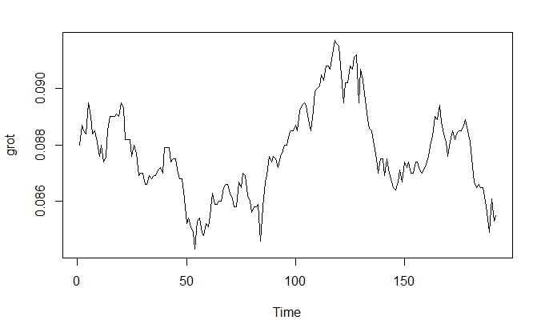

```r
ts.plot(grot)
```

2. Now follow the ARIMA fitting flowchat in your notes. Difference the data using the R function diff() and put it into another vector called dgrot. Plot the differenced data. Does it look stationary in mean? If so, then set the order of differencing d = 1, otherwise difference again and increase d accordingly.

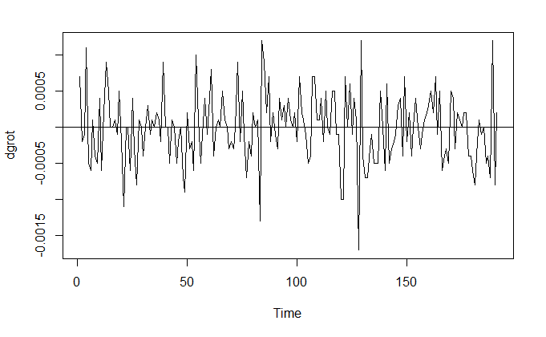

```r
dgrot <- diff(grot) #difference grot
ts.plot(dgrot) #plot differenced series
abline(a=0, b=0) # plot line at y=0
```

This appears to be stationary in mean, as the series seems to gravitate to the y=0 line.

3. Plot the correlogram of the differenced data using the acf() function. Are any of the correlation coefficients much larger than the tolerance limits?

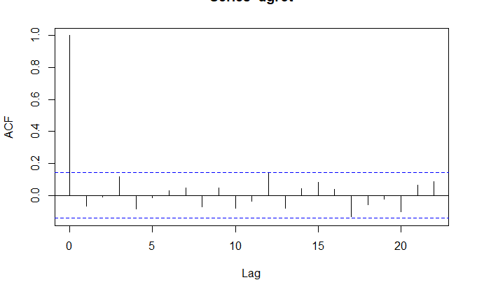

```r
acf(dgrot) #plot autocorrellation of differenced series
```

We can see that the only significant autocorrelative lag is k=0, as it is the only lag on the acf plot which lies outside the hatched area.

4. Plot the partial correlogram of the differenced data. Are any of the partial autocorrelation coefficients much larger than the tolerance limits?

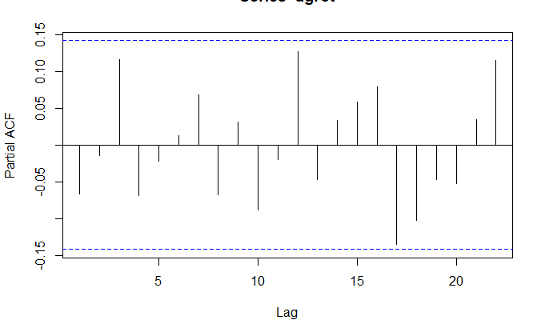

```r
pacf(dgrot) #plot partial autocorrellation of differenced series
```

After accounting for intermediate lags by using the pacf, there are still no significant lags k.

5. Suggest a suitable model for the differenced data and justify your reasons.

I suggest the ARIMA(0,1,0) model. Analysing the differenced d=1 series, the series is stationary and has no significant relationships with previous time steps.